# Workflow

## What is rater?

The {rater} package is designed to allow easy fitting and analysis of Bayesian models of categorical data annotation using [Stan](https://mc-stan.org/). Here we demonstrate the basic workflow for using the package.

## Data

We will use the *anesthesia* data set taken from the paper *Maximum Likelihood Estimation of Observer Error-Rates Using the EM Algorithm* by A. P. Dawid and A. M. Skene, the paper which introduced the original Dawid-Skene model the type of models used This dataset is included in **rater**. We can prepare the package and data with:

```r
# Load the rater package.
library(rater)

# Access the 'anesthesia' data set.
data("anesthesia")
```

The data comes in the form of a `data.frame` with three columns `item`, `rater` and `rating`. In the nomenclature of the package we would describe this as *long* data. *Long* data is the standard data format for passing data to inference functions in {rater}. The `item` column is the index of each item, the `rater` column is the index of the rater and `rating` is the actual rating. For example the twentieth row of the dataset:

```r
anesthesia[20, ]
```

```
#>    item rater rating
#> 20    3     4      2
```

means that item 3 was rated as being in category 2 by the fourth rater. {rater} also allows the use of *grouped* data for fitting some of the models but that feature is not covered in this vignette.

## Inference

The core function of the {rater} package is the `rater()` function which fits a specified categorical rating to model to given data. This function has two arguments: `data`, data in an appropriate format and `model`, a character string or functions specifying the model you would like to fit. By default `rater()` will fit the model using MCMC (specifically NUTS) provided by Stan. To fit the basic Dawid-Skene model[^1] to the anesthesia data we can run.

```r
fit <- rater(anesthesia, "dawid_skene", chains = 1, verbose = FALSE)
```

Note that here we have set `verbose = FALSE` to suppress the normal Stan sampling output. We have also specified that we should use only 1 chain, simply to speed up the creation of the vignette. Other fitting parameters can be passed directly to the underlying Stan functions through the `...` in `rater()`.

We can also compute MAP estimates by specifying `method = "optim"`in `rater()`:

```r
optim_fit <- rater(anesthesia, "dawid_skene", method = "optim")
```

## Plotting

Having fit the Dawid and Skene model to the data we can now plot parameter estimates from the model.

To plot the population prevalence estimates (the parameter $\pi$ in the model) we run:

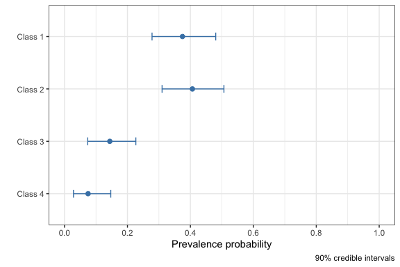

```r
plot(fit, pars = "pi")
```

To plot the rater’s error’s matrices of the (the parameter $\theta$ in the model) we run:

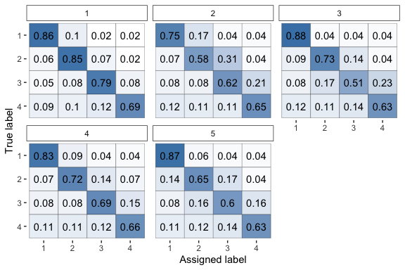

```r
plot(fit, pars = "theta")
```

To plot the latent class estimates we run:

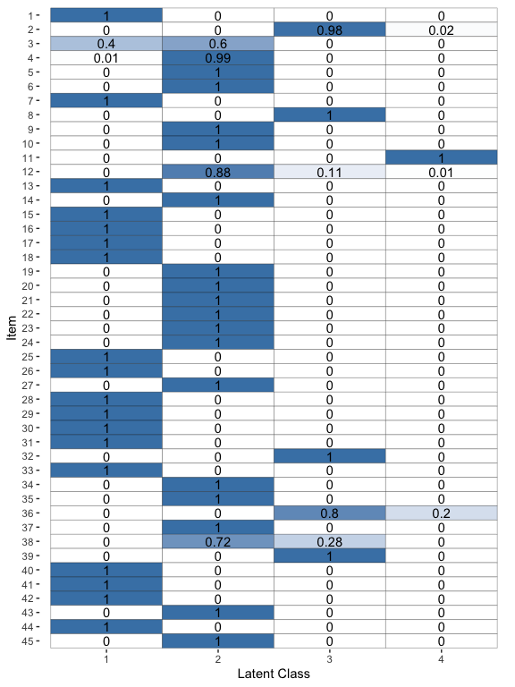

```r
plot(fit, pars = "latent_class")
```

## Point estimates

In additions we can extract point estimates for all the parameters. These can be extracted using the `point_estimates()` function. Different parameters can be extracted using the `pars` argument i.e.

```r
# Extract all parameters.
all_parameters <- point_estimate(fit)

# Extract only the 'pi' parameter.
point_estimate(fit, pars = "pi")
```

```
#> $pi
#> [1] 0.37486986 0.40640862 0.14389118 0.07483033
```

Note that the interpretation of the point estimates returned will differ depending on whether the model has been fit using MCMC or optimisation.

## Other functions

{rater} also supports a variety of other functions to extract useful quantities from fit objects which are listed below:

- `posterior_samples()`
- `posterior_interval()`
- `class_probabilities()`
- `mcmc_diagnostics()`

Hopefully the uses of these functions are fairly self explanatory.

[^1]: {rater} also supports the ‘class conditional’ and ‘hierarchical’ Dawid-Skene models as well as setting (some of) the prior parameters in all three models.